# 数据挖掘互评作业四：离群点分析与异常检测

1. 问题描述

   本次作业将从Anomaly Detection Meta-Analysis Benchmarks提供的benchmark数据集中任选两个进行分析。
2. 数据来源

   Anomaly Detection Meta-Analysis Benchmarks  
   注意：第一个不是数据集，是用于生成benchmark数据的代码。  
   可以使用Python Outlier Detection (PyOD)或其他已知的工具包来完成分析工作。
3. 提交的内容

   完整的分析代码  
   分析报告：展示分析的思路，详细过程，结果及你的分析。  
   所选择的数据集在README中说明，数据文件不要上传到Github中  
   乐学平台提交注意事项：  
   仓库地址：记得加上  
   报告：附件，word，pdf，html格式都可以

```python
import os
from google.colab import drive
drive.mount('/content/drive') # mount google drive
co_path = '/content/drive/My Drive/Colab Notebooks/dataMining'
os.chdir(co_path)
# os.listdir(co_path)
```

```python
!pip3 install pyod
```

```
     |████████████████████████████████| 102kB 2.4MB/s
     |████████████████████████████████| 2.1MB 8.1MB/s
```

```python
import numpy as np
import scipy as sp
import pandas as pd
import matplotlib.pyplot as plt
import seaborn as sns
import json
import math
import re
import sys
import csv
import os

import warnings

warnings.filterwarnings('ignore')
```

## 1 下载数据集

Download pageb_benchmarks

```python
#wget https://ir.library.oregonstate.edu/downloads/1g05fh87w?locale=en -O pageb_benchmarks.zip
```

[output not shown]

### 加载并分析pageb_benchmarks数据集的文件组成

该数据集在pageb.original.csv的基础上处理后的数据共有940个csv文件，分别添加了不同的噪声。

```python
import glob
import zipfile

zf = zipfile.ZipFile('pageb_benchmarks.zip')
print('fileNamelist',len(zf.namelist()))
zf.namelist()[:15]
```

```
fileNamelist 952
```

```
['pageb/',
 'pageb/HELP-README',
 'pageb/CREATIVE-COMMONS-ATTRIBUTION-LICENSE-4.0',
 'pageb/LICENSE-README',
 'pageb/meta_data/',
 'pageb/meta_data/pageb.diff.csv',
 'pageb/meta_data/pageb.original.dat',
 'pageb/meta_data/meta_pageb.csv',
 'pageb/meta_data/pageb.preproc.csv',
 'pageb/meta_data/notes.txt',
 'pageb/meta_data/pageb.original.csv',
 'pageb/benchmarks/',
 'pageb/benchmarks/pageb_benchmark_0308.csv',
 'pageb/benchmarks/pageb_benchmark_0657.csv',
 'pageb/benchmarks/pageb_benchmark_0964.csv']
```

```python
data_csvs = list(filter(lambda f: f.startswith('pageb/benchmarks/pageb_benchmark_'),zf.namelist()))
len(data_csvs)
```

```
940
```

```python
# 读取并合并整个数据集，即合并所有940个csv文件的数据
%%time
dfs = [pd.read_csv(zf.open(f)) for f in data_csvs]
wave = pd.concat(dfs,ignore_index=True)
```

```
CPU times: user 33.1 s, sys: 2.4 s, total: 35.5 s
Wall time: 35.8 s
```

## 2 分析数据集特征（列）

合并后的数据集共有46列

```python
print(wave.shape)
wave.head(10)
```

```
(3180315, 46)
```

|  | point.id | motherset | origin | original.label | diff.score | ground.truth | V | V.1 | V.2 | V.3 | V.4 | V.5 | V.6 | V.7 | V.8 | V.9 | noise..1 | noise..2 | noise..3 | noise..4 | noise..5 | noise..6 | noise..7 | noise..8 | noise..9 | noise..10 | noise..11 | noise..12 | noise..13 | … |
| --- | --- | --- | --- | --- | --- | --- | --- | --- | --- | --- | --- | --- | --- | --- | --- | --- | --- | --- | --- | --- | --- | --- | --- | --- | --- | --- | --- | --- | --- | --- |
| 0 | pageb_point_0532 | pageb | multiclass | 1 | 0.025237 | nominal | -0.077700 | -0.719726 | -0.234134 | -0.422619 | -0.374908 | -1.066748 | -0.062527 | -0.273102 | -0.373695 | -0.577753 | -0.350250 | -0.183182 | 0.067753 | 0.818737 | NaN | NaN | NaN | NaN | NaN | NaN | NaN | NaN | NaN | … |
| 1 | pageb_point_0089 | pageb | multiclass | 2 | 0.816461 | anomaly | -0.446887 | -0.606408 | -0.238877 | -0.122264 | 2.286032 | 0.380563 | 0.358730 | -0.263656 | -0.375821 | -0.631546 | -0.281040 | -0.024959 | -0.263656 | -0.236104 | NaN | NaN | NaN | NaN | NaN | NaN | NaN | NaN | NaN | … |
| 2 | pageb_point_2640 | pageb | multiclass | 1 | 0.005073 | nominal | -0.077700 | -0.580258 | -0.204440 | -0.364711 | -0.037368 | 0.269231 | -0.062237 | -0.229019 | -0.302475 | -0.404420 | -0.415388 | -0.024959 | -0.247912 | -0.195170 | NaN | NaN | NaN | NaN | NaN | NaN | NaN | NaN | NaN | … |
| 3 | pageb_point_3466 | pageb | multiclass | 2 | 0.012449 | anomaly | -0.446887 | 3.891431 | -0.026066 | 8.280621 | 0.952749 | -0.281567 | 0.349610 | 0.166153 | 0.025986 | -0.523960 | -0.397280 | -0.235923 | 0.122857 | 0.202364 | NaN | NaN | NaN | NaN | NaN | NaN | NaN | NaN | NaN | … |
| 4 | pageb_point_3640 | pageb | multiclass | 1 | 0.115508 | nominal | 0.766157 | 3.534044 | 2.304749 | 0.196915 | 0.536450 | 0.978238 | 0.016079 | 4.236739 | 5.865462 | 4.048435 | -0.232642 | -0.288664 | -0.170767 | -0.244763 | NaN | NaN | NaN | NaN | NaN | NaN | NaN | NaN | NaN | … |
| 5 | pageb_point_4881 | pageb | multiclass | 1 | 0.098980 | nominal | -0.077700 | 1.180524 | 0.170454 | 0.366275 | -0.959977 | -0.258129 | -0.069620 | 0.026819 | 0.403875 | 1.053965 | -0.171118 | 0.713416 | -0.214850 | -0.281761 | NaN | NaN | NaN | NaN | NaN | NaN | NaN | NaN | NaN | … |
| 6 | pageb_point_3308 | pageb | multiclass | 1 | 0.007007 | nominal | -0.024959 | -0.484374 | -0.177014 | -0.337222 | -0.369282 | 0.087585 | -0.063829 | -0.206978 | -0.249326 | -0.296834 | 1.433833 | -0.130441 | -0.200680 | -0.166831 | NaN | NaN | NaN | NaN | NaN | NaN | NaN | NaN | NaN | … |
| 7 | pageb_point_1527 | pageb | multiclass | 1 | 0.017569 | nominal | -0.288664 | -0.405923 | -0.202790 | -0.167862 | -0.763079 | 0.087585 | -0.070489 | -0.248699 | -0.302475 | -0.416374 | -0.390961 | 5.671074 | -0.261294 | 0.059094 | NaN | NaN | NaN | NaN | NaN | NaN | NaN | NaN | NaN | … |
| 8 | pageb_point_0779 | pageb | multiclass | 1 | 0.005101 | nominal | -0.077700 | -0.597692 | -0.208152 | -0.371974 | -0.020491 | 0.702839 | -0.056736 | -0.233742 | -0.303007 | -0.458213 | -0.359565 | -0.130441 | -0.205403 | -0.276251 | NaN | NaN | NaN | NaN | NaN | NaN | NaN | NaN | NaN | … |
| 9 | pageb_point_3567 | pageb | multiclass | 1 | 0.137141 | nominal | -0.183182 | 0.640086 | -0.011838 | 0.310452 | -0.881218 | 0.269231 | -0.071068 | -0.097558 | 0.109961 | 0.468220 | -0.136725 | -0.235923 | 0.022883 | -0.278613 | NaN | NaN | NaN | NaN | NaN | NaN | NaN | NaN | NaN | … |

```python
wave.info(null_counts=True)
```

```
<class 'pandas.core.frame.DataFrame'>
RangeIndex: 3180315 entries, 0 to 3180314
Data columns (total 46 columns):
 #   Column          Non-Null Count    Dtype
---  ------          --------------    -----
 0   point.id        3180315 non-null  object
 1   motherset       3180315 non-null  object
 2   origin          3180315 non-null  object
 3   original.label  3180315 non-null  int64
 4   diff.score      3180315 non-null  float64
 5   ground.truth    3180315 non-null  object
 6   V               3180315 non-null  float64
 7   V.1             3180315 non-null  float64
 8   V.2             3180315 non-null  float64
 9   V.3             3180315 non-null  float64
```

[output cut: 38 more lines]

### 3 数据集预处理

因为合并后的数据集某些列的值为NAN，因此抽取940个csv文件的共有特征进行训练和预测

```python
select_features = ['V', 'V.1', 'V.2', 'V.3', 'V.4', 'V.5', 'V.6', 'V.7', 'V.8', 'V.9', 'ground.truth']
```

```python
sel_wave = wave[select_features]
```

```python
print(sel_wave.shape)
sel_wave.head(10)
```

```
(3180315, 11)
```

|  | V | V.1 | V.2 | V.3 | V.4 | V.5 | V.6 | V.7 | V.8 | V.9 | ground.truth |
| --- | --- | --- | --- | --- | --- | --- | --- | --- | --- | --- | --- |
| 0 | -0.077700 | -0.719726 | -0.234134 | -0.422619 | -0.374908 | -1.066748 | -0.062527 | -0.273102 | -0.373695 | -0.577753 | nominal |
| 1 | -0.446887 | -0.606408 | -0.238877 | -0.122264 | 2.286032 | 0.380563 | 0.358730 | -0.263656 | -0.375821 | -0.631546 | anomaly |
| 2 | -0.077700 | -0.580258 | -0.204440 | -0.364711 | -0.037368 | 0.269231 | -0.062237 | -0.229019 | -0.302475 | -0.404420 | nominal |
| 3 | -0.446887 | 3.891431 | -0.026066 | 8.280621 | 0.952749 | -0.281567 | 0.349610 | 0.166153 | 0.025986 | -0.523960 | anomaly |
| 4 | 0.766157 | 3.534044 | 2.304749 | 0.196915 | 0.536450 | 0.978238 | 0.016079 | 4.236739 | 5.865462 | 4.048435 | nominal |
| 5 | -0.077700 | 1.180524 | 0.170454 | 0.366275 | -0.959977 | -0.258129 | -0.069620 | 0.026819 | 0.403875 | 1.053965 | nominal |
| 6 | -0.024959 | -0.484374 | -0.177014 | -0.337222 | -0.369282 | 0.087585 | -0.063829 | -0.206978 | -0.249326 | -0.296834 | nominal |
| 7 | -0.288664 | -0.405923 | -0.202790 | -0.167862 | -0.763079 | 0.087585 | -0.070489 | -0.248699 | -0.302475 | -0.416374 | nominal |
| 8 | -0.077700 | -0.597692 | -0.208152 | -0.371974 | -0.020491 | 0.702839 | -0.056736 | -0.233742 | -0.303007 | -0.458213 | nominal |
| 9 | -0.183182 | 0.640086 | -0.011838 | 0.310452 | -0.881218 | 0.269231 | -0.071068 | -0.097558 | 0.109961 | 0.468220 | nominal |

```python
sel_wave.info(null_counts=True)
```

```
<class 'pandas.core.frame.DataFrame'>
RangeIndex: 3180315 entries, 0 to 3180314
Data columns (total 11 columns):
 #   Column        Non-Null Count    Dtype
---  ------        --------------    -----
 0   V             3180315 non-null  float64
 1   V.1           3180315 non-null  float64
 2   V.2           3180315 non-null  float64
 3   V.3           3180315 non-null  float64
 4   V.4           3180315 non-null  float64
 5   V.5           3180315 non-null  float64
 6   V.6           3180315 non-null  float64
 7   V.7           3180315 non-null  float64
 8   V.8           3180315 non-null  float64
 9   V.9           3180315 non-null  float64
 10  ground.truth  3180315 non-null  object
dtypes: float64(10), object(1)
memory usage: 266.9+ MB
```

```python
sel_wave['ground.truth'][sel_wave['ground.truth']!='nominal'] = 1
sel_wave['ground.truth'][sel_wave['ground.truth']=='nominal'] = 0
```

```python
np.unique(sel_wave['ground.truth'].values)
```

```
array([0, 1], dtype=object)
```

## 4 离群点与异常点检测

### 4.1 数据集划分

```python
## 去除重复数据
%%time
wave_unique = sel_wave.drop_duplicates()
```

```
CPU times: user 700 ms, sys: 10.8 ms, total: 711 ms
Wall time: 713 ms
```

```python
wave_unique.info(null_counts=True)
```

```
<class 'pandas.core.frame.DataFrame'>
Int64Index: 5403 entries, 0 to 72866
Data columns (total 11 columns):
 #   Column        Non-Null Count  Dtype
---  ------        --------------  -----
 0   V             5403 non-null   float64
 1   V.1           5403 non-null   float64
 2   V.2           5403 non-null   float64
 3   V.3           5403 non-null   float64
 4   V.4           5403 non-null   float64
 5   V.5           5403 non-null   float64
 6   V.6           5403 non-null   float64
 7   V.7           5403 non-null   float64
 8   V.8           5403 non-null   float64
 9   V.9           5403 non-null   float64
 10  ground.truth  5403 non-null   object
dtypes: float64(10), object(1)
memory usage: 506.5+ KB
```

按照80%训练集，20%测试集进行划分

```python
from sklearn.model_selection import train_test_split

train, test = train_test_split(wave_unique, test_size=0.2, random_state=113)
```

```python
y_train = train['ground.truth'].values
y_train = y_train.astype(np.int32)
X_train = train.drop('ground.truth',axis=1).values

y_test = test['ground.truth'].values
y_test = y_test.astype(np.int32)
X_test = test.drop('ground.truth',axis=1).values
```

```python
from sklearn.utils.multiclass import type_of_target
type_of_target(y_train)
```

```
'binary'
```

### 4.2 t-SNE 降维，可视化

```python
from sklearn.manifold import TSNE
```

```python
%%time
tsne_X_train = TSNE(n_components=2,random_state=113,
                    init='pca',n_iter=2000).fit_transform(X_train)

tsne_X_test =  TSNE(n_components=2,random_state=113,
                    init='pca',n_iter=2000).fit_transform(X_test)
```

```
CPU times: user 2min 34s, sys: 586 ms, total: 2min 35s
Wall time: 1min 19s
```

```python
%%time
from pyod.models.knn import KNN

clf_name = "KNN"
clf = KNN()
clf.fit(X_train)

y_train_pred = clf.labels_
y_train_scores = clf.decision_scores_

y_test_pred = clf.predict(X_test)
y_test_scores = clf.decision_function(X_test)
```

```
CPU times: user 587 ms, sys: 62.4 ms, total: 649 ms
Wall time: 1.66 s
```

### 4.3 方法比较

- 单一数据模型
  - KNN
  - PCA
  - LOF
- 组合模型
  - Average: average scores of all detectors.
  - maximization: maximum score across all detectors.
  - Average of Maximum (AOM): divide base detectors into subgroups and take the maximum score for each subgroup. The final score is the average of all subgroup scores.
  - Maximum of Average (MOA): divide base detectors into subgroups and take the average score for each subgroup. The final score is the maximum of all subgroup scores.

#### KNN

```python
from pyod.utils.data import evaluate_print
# evaluate and print the results
print("\nOn Training Data:")
evaluate_print(clf_name, y_train, y_train_scores)
print("\nOn Test Data:")
evaluate_print(clf_name, y_test, y_test_scores)
```

```
On Training Data:
KNN ROC:0.8545, precision @ rank n:0.4913

On Test Data:
KNN ROC:0.8586, precision @ rank n:0.4602
```

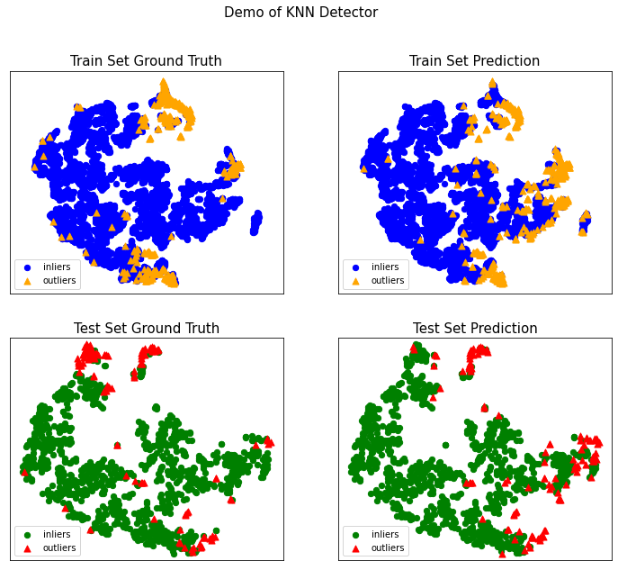

```
CPU times: user 391 ms, sys: 8.05 ms, total: 399 ms
Wall time: 416 ms
```

```python
%%time
from pyod.utils.example import visualize
visualize(clf_name, tsne_X_train, y_train, tsne_X_test, y_test, y_train_pred,
    y_test_pred, show_figure=True, save_figure=False)
```

#### PCA

```python
%%time
from pyod.models.pca import PCA
clf_name = 'PCA'
clf = PCA(n_components=3)
clf.fit(X_train)

y_train_pred = clf.labels_
y_train_scores = clf.decision_scores_

y_test_pred = clf.predict(X_test)
y_test_scores = clf.decision_function(X_test)
```

```
CPU times: user 9.38 ms, sys: 12 ms, total: 21.4 ms
Wall time: 22 ms
```

```python
# evaluate and print the results
print("\nOn Training Data:")
evaluate_print(clf_name, y_train, y_train_scores)
print("\nOn Test Data:")
evaluate_print(clf_name, y_test, y_test_scores)
```

```
On Training Data:
PCA ROC:0.8924, precision @ rank n:0.4564

On Test Data:
PCA ROC:0.8921, precision @ rank n:0.4779
```

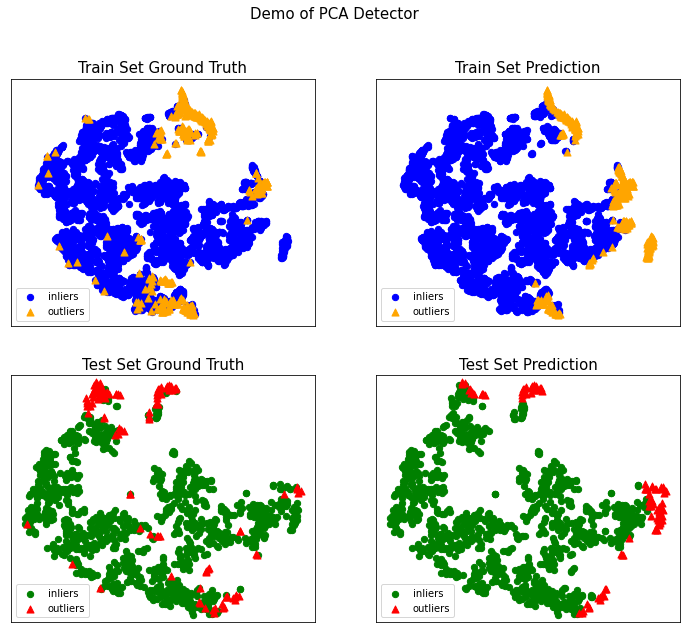

```
CPU times: user 291 ms, sys: 1.94 ms, total: 293 ms
Wall time: 294 ms
```

```python
%%time
visualize(clf_name, tsne_X_train, y_train, tsne_X_test, y_test, y_train_pred,
    y_test_pred, show_figure=True, save_figure=False)
```

#### LOF

```python
%%time
from pyod.models.lof import LOF

clf_name = "LOF"
clf = LOF()
clf.fit(X_train)

y_train_pred = clf.labels_
y_train_scores = clf.decision_scores_

y_test_pred = clf.predict(X_test)
y_test_scores = clf.decision_function(X_test)
```

```
CPU times: user 252 ms, sys: 995 µs, total: 253 ms
Wall time: 256 ms
```

```python
# evaluate and print the results
print("\nOn Training Data:")
evaluate_print(clf_name, y_train, y_train_scores)
print("\nOn Test Data:")
evaluate_print(clf_name, y_test, y_test_scores)
```

```
On Training Data:
LOF ROC:0.7292, precision @ rank n:0.3566

On Test Data:
LOF ROC:0.7065, precision @ rank n:0.3009
```

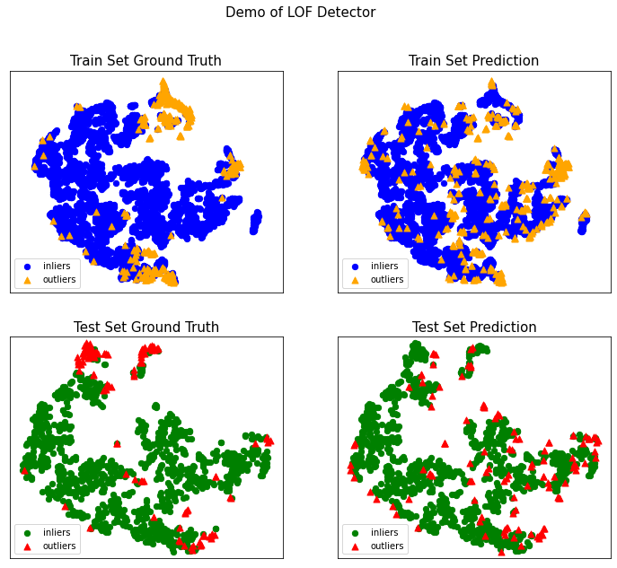

```
CPU times: user 287 ms, sys: 6.99 ms, total: 294 ms
Wall time: 297 ms
```

```python
%%time
visualize(clf_name, tsne_X_train, y_train, tsne_X_test, y_test, y_train_pred,
    y_test_pred, show_figure=True, save_figure=False)
```

#### 组合模型

```python
from pyod.models.combination import aom,moa,average,maximization
from pyod.utils.utility import standardizer
```

```python
%%time
norm_X_train,norm_X_test = standardizer(X_train,X_test)

n_clf = 20 # initialize 20 base detectors for combination

k_list = [10, 20, 30, 40, 50, 60, 70, 80, 90, 100, 110, 120, 130, 140,
            150, 160, 170, 180, 190, 200]

train_scores = np.zeros([norm_X_train.shape[0], n_clf])
test_scores = np.zeros([norm_X_test.shape[0], n_clf])

for i in range(n_clf):
    k = k_list[i]

    clf = KNN(n_neighbors=k, method='largest')
    clf.fit(norm_X_train)

    train_scores[:, i] = clf.decision_scores_
    test_scores[:, i] = clf.decision_function(norm_X_test)
```

```
CPU times: user 9.89 s, sys: 7.01 ms, total: 9.9 s
Wall time: 9.9 s
```

```python
%%time
# Decision scores have to be normalized before combination
train_scores_norm, test_scores_norm = standardizer(train_scores, test_scores)

comb_by_average = average(test_scores_norm)
comb_by_maximization = maximization(test_scores_norm)
comb_by_aom = aom(test_scores_norm, 5) # 5 groups
comb_by_moa = moa(test_scores_norm, 5) # 5 groups
```

```
CPU times: user 7.36 ms, sys: 20 µs, total: 7.38 ms
Wall time: 8.55 ms
```

```python
%%time
print("\nOn Test Data:")
evaluate_print('Combination by Average', y_test, comb_by_average)
evaluate_print('Combination by Maximization', y_test, comb_by_maximization)
evaluate_print('Combination by AOM', y_test, comb_by_aom)
evaluate_print('Combination by MOA', y_test, comb_by_moa)
```

```
On Test Data:
Combination by Average ROC:0.9242, precision @ rank n:0.5133
Combination by Maximization ROC:0.9231, precision @ rank n:0.5133
Combination by AOM ROC:0.9242, precision @ rank n:0.5133
Combination by MOA ROC:0.9243, precision @ rank n:0.5133
CPU times: user 15.9 ms, sys: 993 µs, total: 16.9 ms
Wall time: 20.3 ms
```

## 5 单独分析某个csv文件

对每个benchmars的csv文件单独使用KNN，PCA，LOF三种模型进行离群点和异常点检测。

```python
from sklearn.utils import column_or_1d
from sklearn.utils import check_consistent_length
from sklearn.metrics import roc_auc_score

from pyod.utils.utility import precision_n_scores
import time
```

```python
def data_label_split(data, label_column='ground.truth'):
    x = data.drop(label_column, axis=1)
    y = []
    for i in data[label_column].values:
        if i == 'nominal':
            y.append(0)
        else:
            y.append(1)
    y = np.array(y)
    return x, y

def evaluate(y, y_pred):
    y = column_or_1d(y)
    y_pred = column_or_1d(y_pred)
    check_consistent_length(y, y_pred)
    return np.round(roc_auc_score(y, y_pred), decimals=4), np.round(precision_n_scores(y, y_pred), decimals=4)

def tsne(original_data):
    # T-SNE Implementation
    t0 = time.time()
    reduced_tsne = TSNE(n_components=2, random_state=2020, init='pca').fit_transform(original_data.values)
    t1 = time.time()
    print("T-SNE took {:.2} s".format(t1 - t0))
    return reduced_tsne

# fit model in unsupervised manner and predict
def model_evaluation(clf, data):
    X_train, y_train = data_label_split(data)
    clf.fit(X_train)

    # get the prediction labels and outlier scores of the training data
    y_train_pred = clf.labels_  # binary labels (0: inliers, 1: outliers)
    y_train_scores = clf.decision_scores_  # raw outlier scores
    roc, prn = evaluate(y_train, y_train_scores)
    return y_train_pred, roc, prn
```

```python
import matplotlib.patches as mpatches
import matplotlib.pyplot as plt

def visualization(data, y_pred):
    X_train, y_train = data_label_split(data)
    X_reduced_tsne = tsne(X_train)
    f, (ax0, ax1) = plt.subplots(1, 2, figsize=(16,6))
    blue_patch = mpatches.Patch(color='#0A0AFF', label='nominal')
    red_patch = mpatches.Patch(color='#AF0000', label='anomaly')

     # true visualization
    ax0.scatter(X_reduced_tsne[:,0], X_reduced_tsne[:,1], c=(y_train == 0), cmap='coolwarm', label='nominal', linewidths=2)
    ax0.scatter(X_reduced_tsne[:,0], X_reduced_tsne[:,1], c=(y_train == 1), cmap='coolwarm', label='anomaly', linewidths=2)
    ax0.set_title('ground-truth t-SNE visualization', fontsize=14)

    ax0.legend(handles=[blue_patch, red_patch])
    ax0.set_xticks([])
    ax0.set_yticks([])

    # predicted visualization
    ax1.scatter(X_reduced_tsne[:,0], X_reduced_tsne[:,1], c=(y_pred == 0), cmap='coolwarm', label='nominal', linewidths=2)
    ax1.scatter(X_reduced_tsne[:,0], X_reduced_tsne[:,1], c=(y_pred == 1), cmap='coolwarm', label='anomaly', linewidths=2)
    ax1.set_title('prediction t-SNE visualization', fontsize=14)

    ax1.legend(handles=[blue_patch, red_patch])
    ax1.set_xticks([])
    ax1.set_yticks([])

    plt.show()
```